# Assignment_MP2

Ritik Kumar

2024-10-25

## Forecast the Insurance Dataset

##### Importing the dataset

```r
library(fpp)
library(fpp2)
```

```r
library(ggplot2)
library(forecast)
library(TTR)
library(readr)
Insurance <- read_csv("C:/Users/malho/Downloads/insurance.csv")
View(Insurance)
```

## 1. Create Timeseries Plot and Inference

##### Considering only Quotes column from January 2002 to April 2005

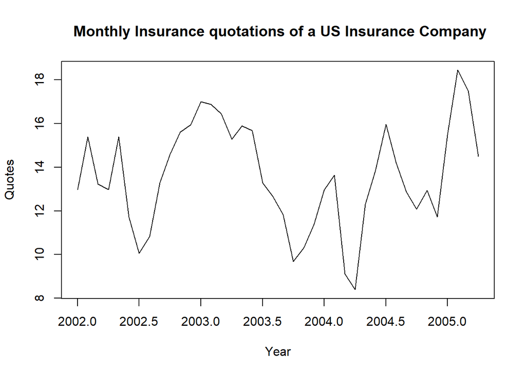

```r
insurance_ts <- ts(Insurance$Quotes, start =c(2002,1), end = c(2005, 4), frequency = 12)

plot(insurance_ts, main = " Monthly Insurance quotations of a US Insurance Company", xlab = "Year", ylab = "Quotes")
```

- we start with plotting the time series for visualize and understand the data.

## 2. Verify how much history to include in your analysis.

```r
summary(insurance_ts)
```

```
##    Min. 1st Qu.  Median    Mean 3rd Qu.    Max.
##   8.395  12.023  13.287  13.604  15.505  18.439
```

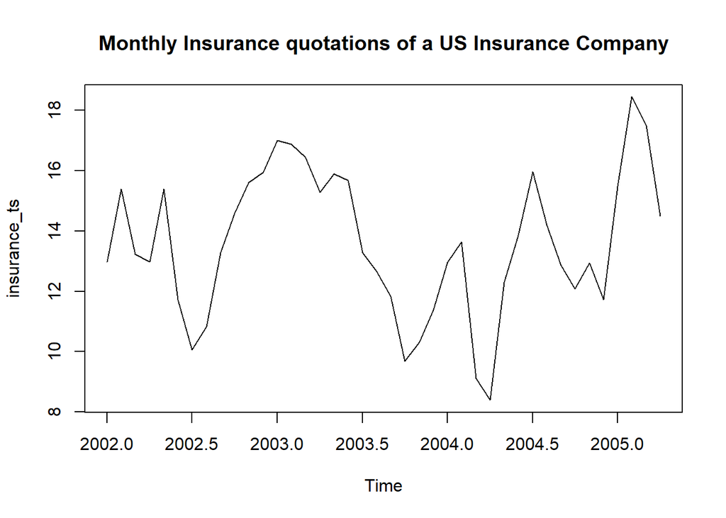

```r
plot(insurance_ts, main = "Monthly Insurance quotations of a US Insurance Company")
```

- The summary function above gives the min, max, mean, median, 1st and 3rd Quarterly values of the times series.
- After that we plot the graph to verify how much history to include in our analysis

## 3. Hypothesize if the dataset has trend, seasonality, or both.

- This will we check after applying Acf and decomposition for finding trend or seasonality in the dataset

##### 4. Verifying using ACF plot to check for seasonality or autocorrelation

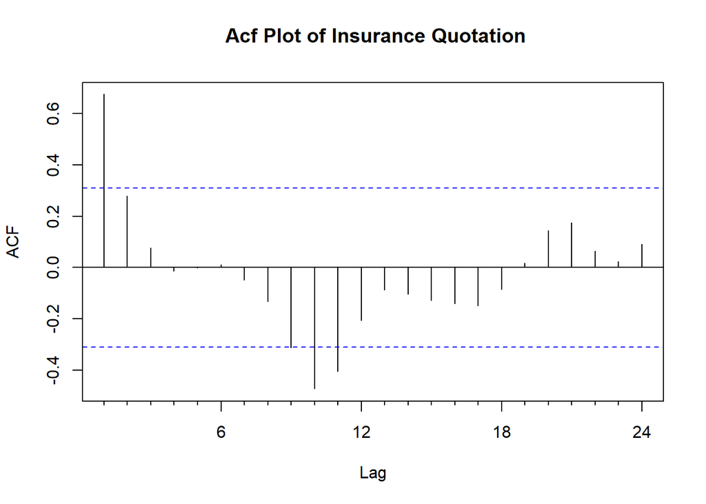

```r
Acf(insurance_ts, main =" Acf Plot of Insurance Quotation")
```

##### 5. Verify using decomposition

##### Decompose the time series to verify trend and seasonality

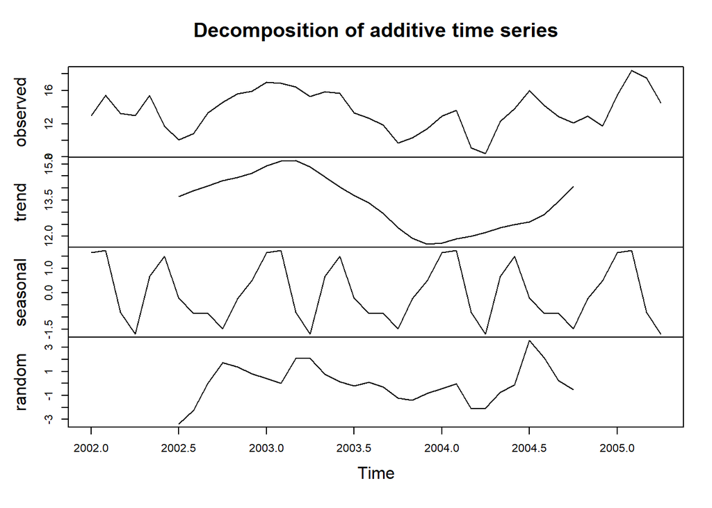

```r
decomp <- decompose(insurance_ts)
plot(decomp)
```

```r
decomp$type
```

```
## [1] "additive"
```

- The decomposition seems to be additive.
- Trend: Long-term movement in the data
- Seasonal: Repeated cycles, usually yearly
- Residual: Random fluctuations that remain after removing trend and seasonality
- Because, with as trend increases, we see there is not a strong increase in the seasonality. The seasonality appears to be repeated cyclically.
- Quotes time series display only weak seasonality.

## 6. Chose an accuracy measure

- We’ll use Mean Absolute Error (MAE) and Root Mean Squared Error (RMSE) for model evaluation. later

## 7. Create a forecast model for the next 12 months. Include Naive, Average, Exponential Smoothing, HoltWinters, and Decomposition (both types).

## Naive model

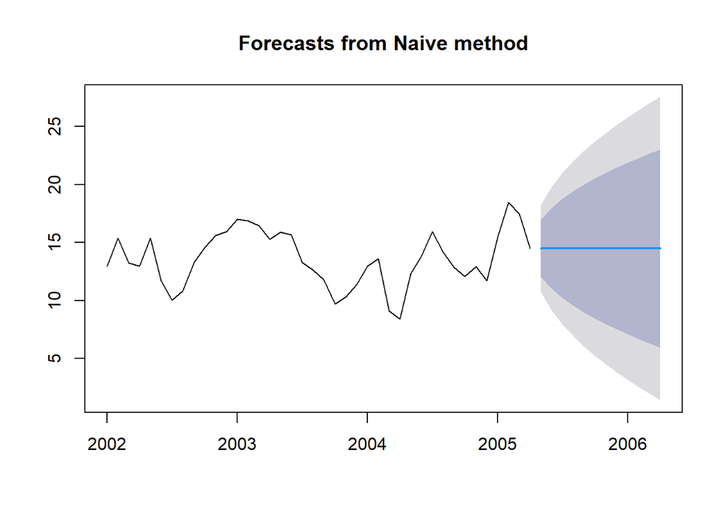

```r
naive_forecast <- naive(insurance_ts, h=12)
plot(naive_forecast)
```

##### Naive Method Summary

- The naive model simply assumes the future will be exactly like the most recent value (no trend or seasonality).

## Simple Moving Averages

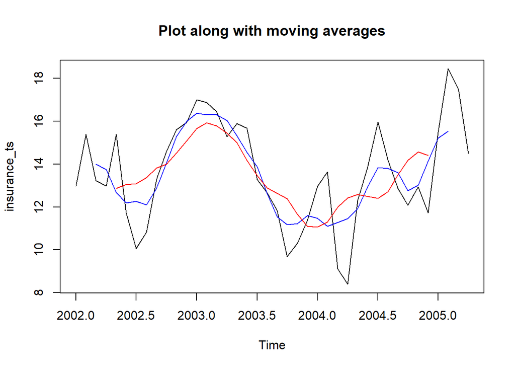

```r
ma5_forecast <- ma(insurance_ts, order =5)
ma9_forecast <- ma(insurance_ts, order =9)
plot(insurance_ts, main ="Plot along with moving averages")
lines(ma5_forecast, col ="Blue")
lines(ma9_forecast, col ="Red")
```

## Exponential Smoothing Model (Simple Exponential Smoothing - SES)

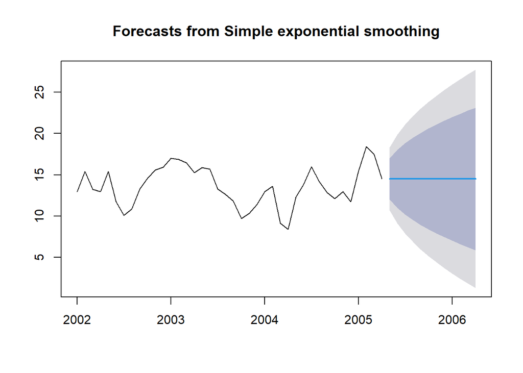

```r
ses_forecast <- ses(insurance_ts, h=12)
plot(ses_forecast)
```

```r
attributes(ses_forecast)
```

```
## $names
##  [1] "model"     "mean"      "level"     "x"         "upper"     "lower"
##  [7] "fitted"    "method"    "series"    "residuals"
##
## $class
## [1] "forecast"
```

##### Exponential Smoothing Model Obervations

- Exponential Smoothing gives more weight to recent observations, making it more responsive to changes.
- From Jan 2002 to March 2004 there is observed to be fluctuated trend.After that there is an increasing trend in the data till April 2005. There is a small gap where no trend observed.So, this forecast may not be a right way to forecast.

## Holt-Winters model - Captures both trend and seasonality.

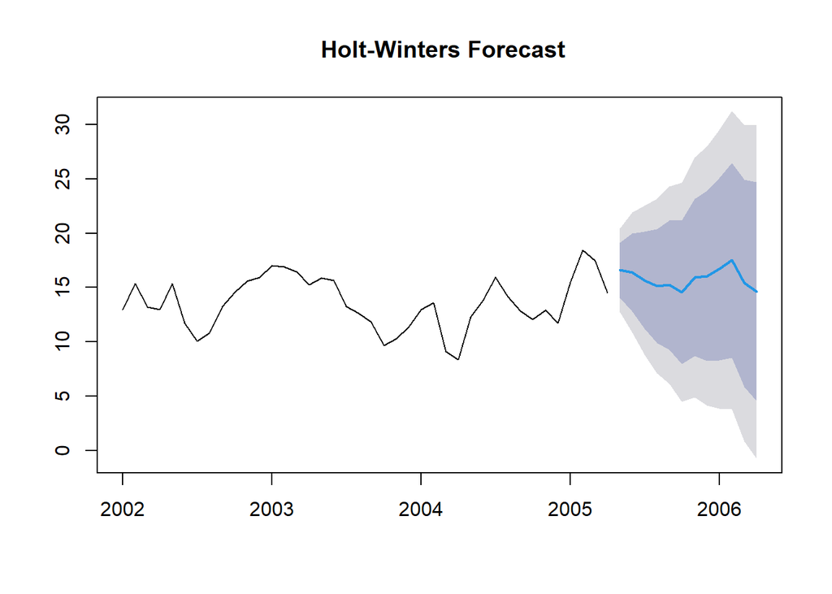

```r
hw_model <- hw(insurance_ts)
hw_forecast <- forecast(hw_model, h=12)
plot(hw_forecast, main=" Holt-Winters Forecast")
```

```r
attributes(hw_forecast)
```

```
## $names
##  [1] "model"     "mean"      "level"     "x"         "upper"     "lower"
##  [7] "fitted"    "method"    "series"    "residuals"
##
## $class
## [1] "forecast"
```

```r
hw_model$model
```

```
## Holt-Winters' additive method
##
## Call:
## hw(y = insurance_ts)
##
##   Smoothing parameters:
##     alpha = 0.9999
##     beta  = 0.0272
##     gamma = 1e-04
##
##   Initial states:
##     l = 13.4243
##     b = -0.1468
##     s = 0.236 0.0967 -1.2543 -0.5618 -0.6536 -0.1118
##            0.6199 0.8343 -1.2545 -0.4778 1.6549 0.8719
##
##   sigma:  1.9646
##
##      AIC     AICc      BIC
## 215.1433 242.9614 243.8542
```

- Here, The Holt-Winters model considers both trend and seasonality, making it suitable for seasonal data.
- This is because the seasonality isn’t increasing with trend. This is an additive time series.

##### Holt-Winters model Observations

- Alpha = 0.9999 Alpha specifies the coefficient for the level smoothing in Holt winters.
- Beta = 0.0272 Beta specifies the coefficient for the trend smoothing in Holt winters.
- Gamma = 1e-04 Gamma specifies the coefficient for the seasonal smoothing in Holt winters.
- Values 1.0 means that the latest value has highest weight.
- Initial states: l = 13.4243 b = -0.1468  
  s = 0.236 0.0967 -1.2543 -0.5618 -0.6536 -0.1118 0.6199 0.8343 -1.2545 -0.4778 1.6549 0.8719
- Sigma = 1.9646 Sigma defines the variance of the forecast values.

## Decomposition-based forecast Model

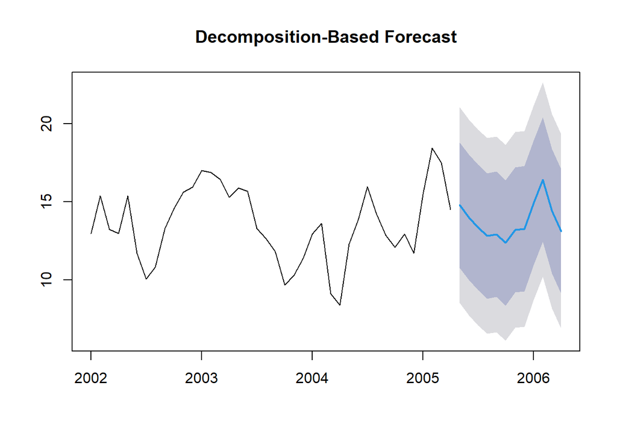

```r
decomp_trend <- tslm(insurance_ts ~ trend + season)
decomp_forecast <- forecast(decomp_trend, h=12)
plot(decomp_forecast, main="Decomposition-Based Forecast")
```

## Decomposition (Additive)

##### Perform additive decomposition Model

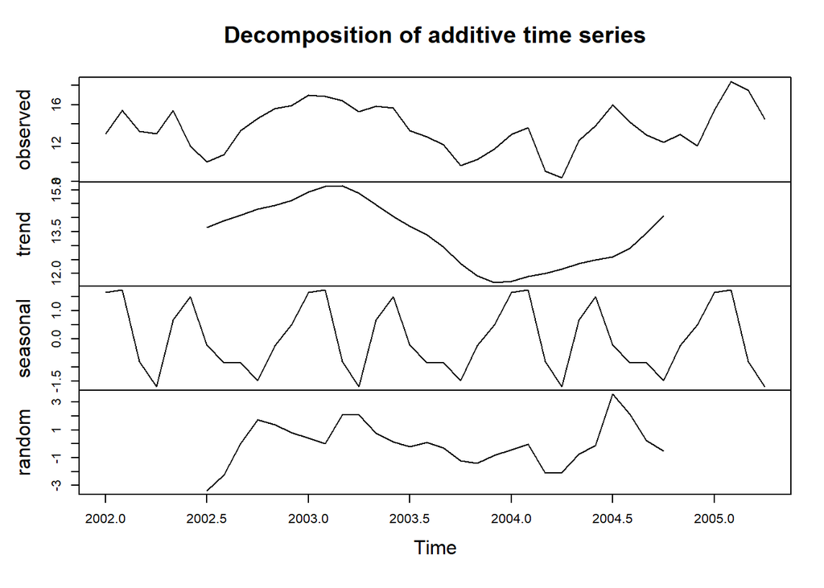

```r
add_decomp <- decompose(insurance_ts, type= "additive")
plot(add_decomp)
```

- Decomposition splits the time series into trend, seasonal, random and observed components.

## Decomposition (Multiplicative)

##### Perform multiplicative decomposition MOdel

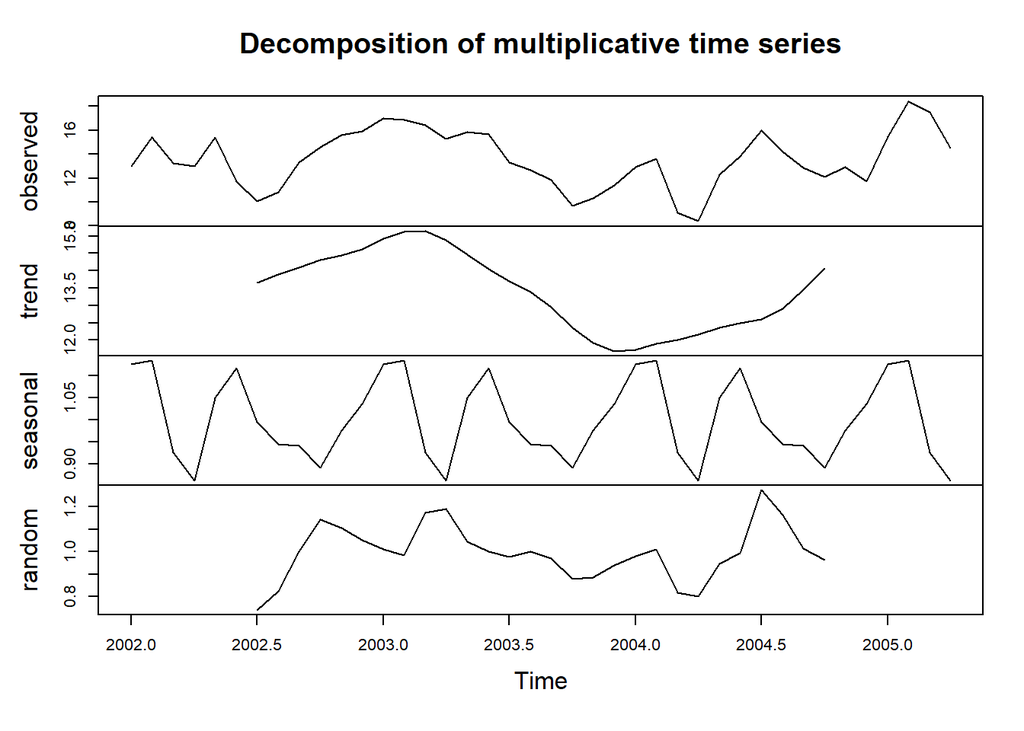

```r
mul_decomp <- decompose(insurance_ts, type ="multiplicative")
plot(mul_decomp)
```

- Multiplicative decomposition is used when the seasonal component changes proportionally to the trend.

## 8.Show model rank with accuracy measures (MAE and RMSE)

```r
naive_acc <- accuracy(naive_forecast)
naive_acc
```

```
##                      ME     RMSE      MAE        MPE     MAPE      MASE
## Training set 0.03900077 1.924326 1.573449 -0.8727077 12.16031 0.4584592
##                  ACF1
## Training set 0.103744
```

```r
ses_acc <- accuracy(ses_forecast)
ses_acc
```

```
##                      ME    RMSE      MAE        MPE     MAPE      MASE
## Training set 0.03789375 1.90014 1.534297 -0.8520511 11.85775 0.4470514
##                   ACF1
## Training set 0.1030891
```

```r
hw_acc <- accuracy(hw_forecast)
hw_acc
```

```
##                     ME     RMSE      MAE       MPE     MAPE      MASE      ACF1
## Training set 0.1461692 1.521735 1.224394 0.3518439 9.201383 0.3567545 0.1785965
```

```r
decomp_acc <- accuracy(decomp_forecast)
decomp_acc
```

```
##                       ME     RMSE      MAE      MPE    MAPE      MASE      ACF1
## Training set 4.45065e-17 2.082549 1.716869 -2.68927 13.5543 0.5002478 0.7636135
```

# Create a summary of accuracy measures (MAE and RMSE)

```r
accuracy_summary <- data.frame(
  Model = c("Naive","Exponential Smoothing", "Holt-Winters", "Decomposition"),
  MAE = c(naive_acc[1, "MAE"], ses_acc[1, "MAE"], hw_acc[1, "MAE"], decomp_acc[1, "MAE"]),
  RMSE = c(naive_acc[1, "RMSE"], ses_acc[1, "RMSE"], hw_acc[1, "RMSE"], decomp_acc[1, "RMSE"])
)

print(accuracy_summary)
```

```
##                   Model      MAE     RMSE
## 1                 Naive 1.573449 1.924326
## 2 Exponential Smoothing 1.534297 1.900140
## 3          Holt-Winters 1.224394 1.521735
## 4         Decomposition 1.716869 2.082549
```

- This table ranks the models based on their accuracy using MAE and RMSE. Lower values indicate better accuracy.

## 9. Choose which models and how are you going to use them for Forecasting

- Based on the accuracy measures, we would select the model with the lowest MAE and RMSE, typically the Holt-Winters or Exponential Smoothing model.

## 10. Provide the forecast for the next 12 months (point and range) and explain why you feel confident with these forecasts

```r
final_forecast <- forecast(hw_model, h=12)
print(final_forecast)
```

```
##          Point Forecast     Lo 80    Hi 80      Lo 95    Hi 95
## May 2005       16.59288 14.075207 19.11055 12.7424310 20.44333
## Jun 2005       16.39019 12.781163 19.99922 10.8706596 21.90972
## Jul 2005       15.67078 11.190837 20.15072  8.8193000 22.52225
## Aug 2005       15.14101  9.898643 20.38337  7.1235028 23.15851
## Sep 2005       15.24483  9.305801 21.18385  6.1618715 24.32778
## Oct 2005       14.56444  7.972919 21.15595  4.4835805 24.64529
## Nov 2005       15.92726  8.714776 23.13975  4.8967153 26.95781
## Dec 2005       16.07874  8.268680 23.88880  4.1342834 28.02320
## Jan 2006       16.72694  8.337148 25.11674  3.8958598 29.55802
## Feb 2006       17.52197  8.566298 26.47765  3.8254509 31.21849
## Mar 2006       15.40104  5.890370 24.91170  0.8557269 29.94635
## Apr 2006       14.63612  4.579076 24.69316 -0.7447997 30.01703
```

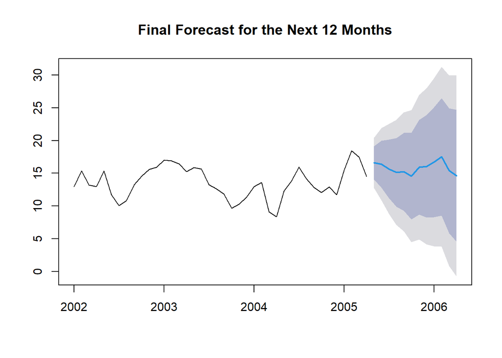

```r
plot(final_forecast, main="Final Forecast for the Next 12 Months")
```

- This is the final forecast, providing point estimates for the next 12 months along with confidence intervals.